# ISLR.Chap6.Ex

## 概念

### 1.

1. 最优子集选择的训练集RSS最小。因为向前和向后逐步选择，采用的是类似贪心(选择当前最好的k，不改变k再加减1)的方法，只能得到局部的最优解。
2. 无法确定哪个模型的测试集RSS最小
3. 1).正确 2).正确 3).错误 4).错误 5).错误

### 2.

1. 与最小二乘模型相比，lasso灵活性更差(less flexible)，并且当lasso的预测结果的偏差增大小于其方差减小时，lasso的预测值更准确
2. 与最小二乘模型相比，ridge灵活性更差(less flexible)，并且当ridge的预测结果的偏差增大小于其方差减小时，ridge的预测值更准确
3. 与最小二乘模型相比，非线性放灵活性更好(more flexible)，并且当非线性模型的预测结果的方差增大小于其偏差减小时，非线性模型的预测值更准确

### 3.

$\sum\limits_{i=1}^{n}{(y_i - \beta_0 - \sum\limits_{j=1}^p{\beta_j x_{ij}})}, \sum\limits_{j=1}^p{|\beta_j|} \le s$ 即lasso  
当s=0时，模型是只包含截距的0模型，也就是说初始条件为$\lambda$无限大时的lasso，s增大即$\lambda$减小

1. 可参考书p153.图6-7  
   随着s从0开始增加，对预测变量系数的限制变小，flexibility增加，训练集的RSS会稳定减小
2. 可参考图6-8  
   随着s从0开始增加，(从0模型)开始有一些变量加入，测试集的RSS会减小，减小到最优的lasso的情况，由于s的增大最终使模型变为*全模型*，测试集的RSS增大。所以是一个先减小后增大的“U”形
3. flexibility增加，方差会稳定增加
4. flexibility增加，平方偏差会稳定减小
5. 不可约误差保持不变

### 4.

$\sum\limits_{i=1}^{n}{(y_i - \beta_0 - \sum\limits_{j=1}^p{\beta_j x_{ij}})} + \lambda\sum\limits_{j=1}^p{\beta_j}^2$ 即ridge  
当$\lambda=0$时，模型是普通最小二乘模型，随着$\lambda$从0开始增加，可参考p150.图6-5

1. 随着$\lambda$从0开始增加，flexibility减小，训练集RSS稳定增大
2. 测试集RSS先减小后增大，呈“U”形
3. 方差稳定减小
4. 平方偏差稳定增大
5. 不可约误差保持不变

### 5.

1. $(y_1 - \hat{\beta_1}x_{11} - \hat{\beta_2}x_{12})^2 + (y_2 - \hat{\beta_1}x_{21} - \hat{\beta_2}x_{22})^2 + \lambda(\hat{\beta_1}^2 + \hat{\beta_2}^2)$

### 6.

$cost = (y_1 - \hat{\beta_1})^2 + {\lambda}\hat{\beta_1}^2$  
$\hat{\beta_j}^R = \frac{y_i}{1+\lambda}$

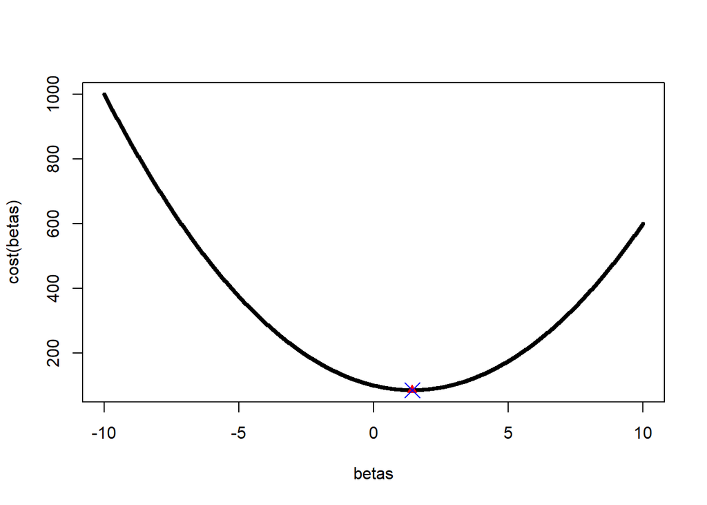

```r
cost <- function(beta, y=10, lambda=6) {
  return((y-beta)^2 + lambda*beta^2)
}
beta_ana_sol <- 10/(1+6)
betas <- seq(-10, 10, length.out = 1000)
beta_num_sol <- betas[which.min(cost(betas))]
plot(betas, cost(betas), cex = 0.5)
points(beta_ana_sol, cost(beta_ana_sol), col = "red", pch = 17)
points(beta_num_sol, cost(beta_num_sol), col = "blue", pch = 4, cex = 2)
```

```r
abs(beta_num_sol - beta_ana_sol)
```

```
## [1] 0.002860003
```

$cost = (y_1 - \hat{\beta_1})^2 + {\lambda}|\hat{\beta_1}|$  
$\hat{\beta_j}^L = \begin{cases} y_j-\frac{\lambda}{2},&{y_j}>{\frac{\lambda}{2}} \\ y_j+\frac{\lambda}{2},&{y_j}<-{\frac{\lambda}{2}} \\ 0,&|y_j|\le {\frac{\lambda}{2}} \end{cases}$

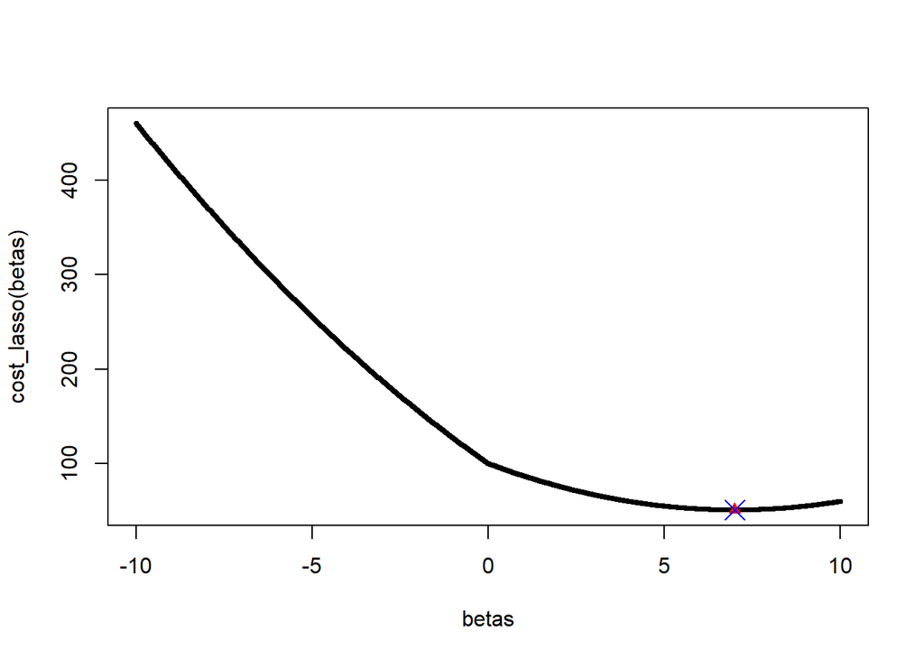

```r
cost_lasso <- function(beta, y=10, lambda=6){
  return((y-beta)^2 + lambda*abs(beta))
}
ana_sol <- function(y, lambda){
  if (y > lambda/2){
    beta <- y - lambda/2
  }else if(y < -lambda/2){
    beta <- y + lambda/2
  }else{
    beta <- 0
  }
  return(beta)
}

beta_ana_sol <- ana_sol(10, 6)
betas <- seq(-10, 10, length.out = 1000)
beta_num_sol <- betas[which.min(cost_lasso(betas))]

plot(betas, cost_lasso(betas), cex = 0.5)
points(beta_ana_sol, cost_lasso(beta_ana_sol), col = "red", pch = 17)
points(beta_num_sol, cost_lasso(beta_num_sol), col = "blue", pch = 4, cex = 2)
```

```r
abs(beta_num_sol - beta_ana_sol)
```

```
## [1] 0.003003003
```

## 应用

### 8.

a.b.

```r
library(leaps)
set.seed(123)
x <- rnorm(100)
set.seed(123)
epsilon <- rnorm(100)
beta0 <- 4
beta1 <- 3
beta2 <- 2
beta3 <- 1
y <- beta0 + beta1*x + beta2*x^2 + beta3*x^3
```

3. 根据$C_p, BIC, adjR^2$来选择regsubsets获得的最优模型  
   据下图的结果来看，最优模型并不相同，但是注意到，当变量数超过3时，各评价指标变化不大，所以可认为3是最佳model size

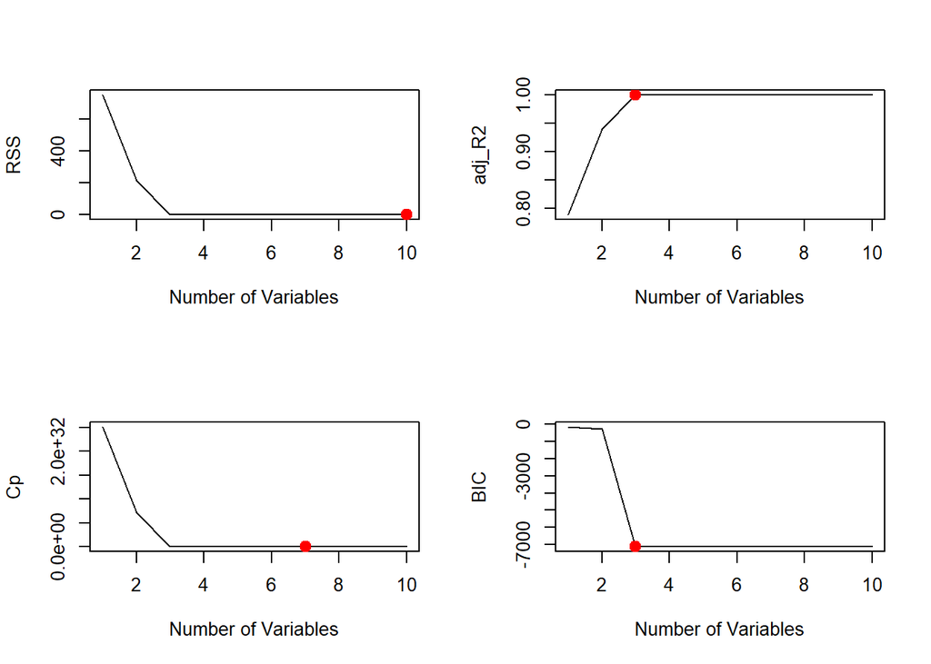

```r
df <- data.frame(
  x,
  y
)
df2 <- data.frame(
  x1 = x,
  x2 = x^2,
  x3 = x^3,
  x4 = x^4,
  x5 = x^5,
  x6 = x^6,
  x7 = x^7,
  x8 = x^8,
  x9 = x^9,
  x10 = x^10,
  y
)
# 如果使用df作为data，则需要在poly()中加上raw=TRUE参数
# 如果使用df2作为data,则可直接用y ~ x拟合
fm <- regsubsets(y ~ poly(x, 10, raw = TRUE), data = df, nvmax = 10)
fm_sum <- summary(fm)
min_rss <- which.min(fm_sum$rss)
max_adjr2 <- which.max(fm_sum$adjr2)
min_cp <- which.min(fm_sum$cp)
min_bic <- which.min(fm_sum$bic)
par(mfrow = c(2, 2))
plot(fm_sum$rss, xlab = "Number of Variables", ylab = "RSS", type = "l")
points(min_rss, fm_sum$rss[min_rss], col = "red", cex = 2, pch = 20)
plot(fm_sum$adjr2, xlab = "Number of Variables", ylab = "adj_R2", type = "l")
points(max_adjr2, fm_sum$adjr2[max_adjr2], col = "red", cex = 2, pch = 20)
plot(fm_sum$cp, xlab = "Number of Variables", ylab = "Cp", type = "l")
points(min_cp, fm_sum$cp[min_cp], col = "red", cex = 2, pch = 20)
plot(fm_sum$bic, xlab = "Number of Variables", ylab = "BIC", type = "l")
points(min_bic, fm_sum$bic[min_bic], col = "red", cex = 2, pch = 20)
```

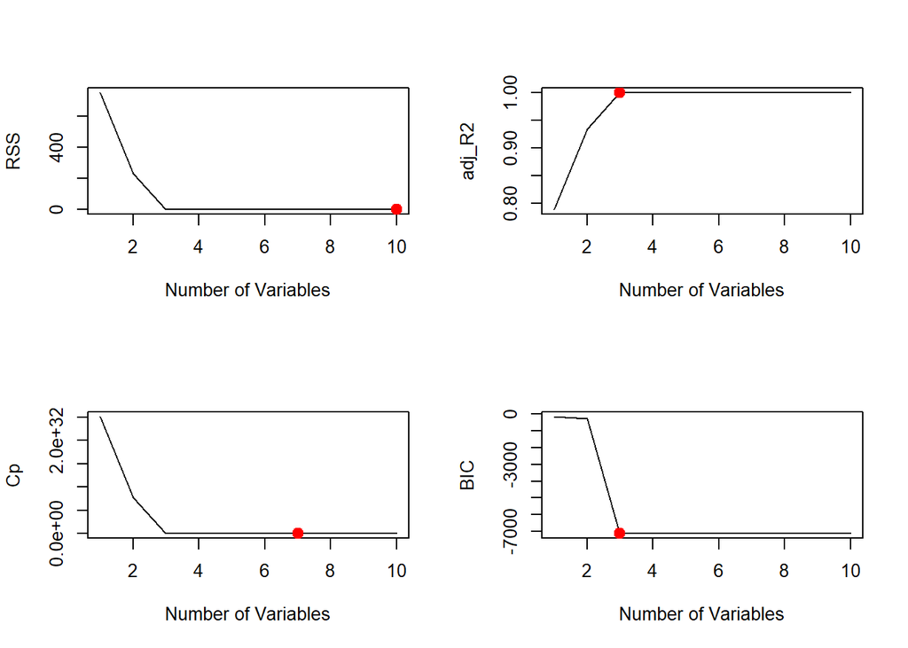

```r
# forward
fm_fwd <- regsubsets(y ~ poly(x, 10, raw = TRUE), data = df, nvmax = 10, method = "forward")
fm_fwd_sum <- summary(fm_fwd)
min_rss <- which.min(fm_fwd_sum$rss)
max_adjr2 <- which.max(fm_fwd_sum$adjr2)
min_cp <- which.min(fm_fwd_sum$cp)
min_bic <- which.min(fm_fwd_sum$bic)
par(mfrow = c(2, 2))
plot(fm_fwd_sum$rss, xlab = "Number of Variables", ylab = "RSS", type = "l")
points(min_rss, fm_fwd_sum$rss[min_rss], col = "red", cex = 2, pch = 20)
plot(fm_fwd_sum$adjr2, xlab = "Number of Variables", ylab = "adj_R2", type = "l")
points(max_adjr2, fm_fwd_sum$adjr2[max_adjr2], col = "red", cex = 2, pch = 20)
plot(fm_fwd_sum$cp, xlab = "Number of Variables", ylab = "Cp", type = "l")
points(min_cp, fm_fwd_sum$cp[min_cp], col = "red", cex = 2, pch = 20)
plot(fm_fwd_sum$bic, xlab = "Number of Variables", ylab = "BIC", type = "l")
points(min_bic, fm_fwd_sum$bic[min_bic], col = "red", cex = 2, pch = 20)
```

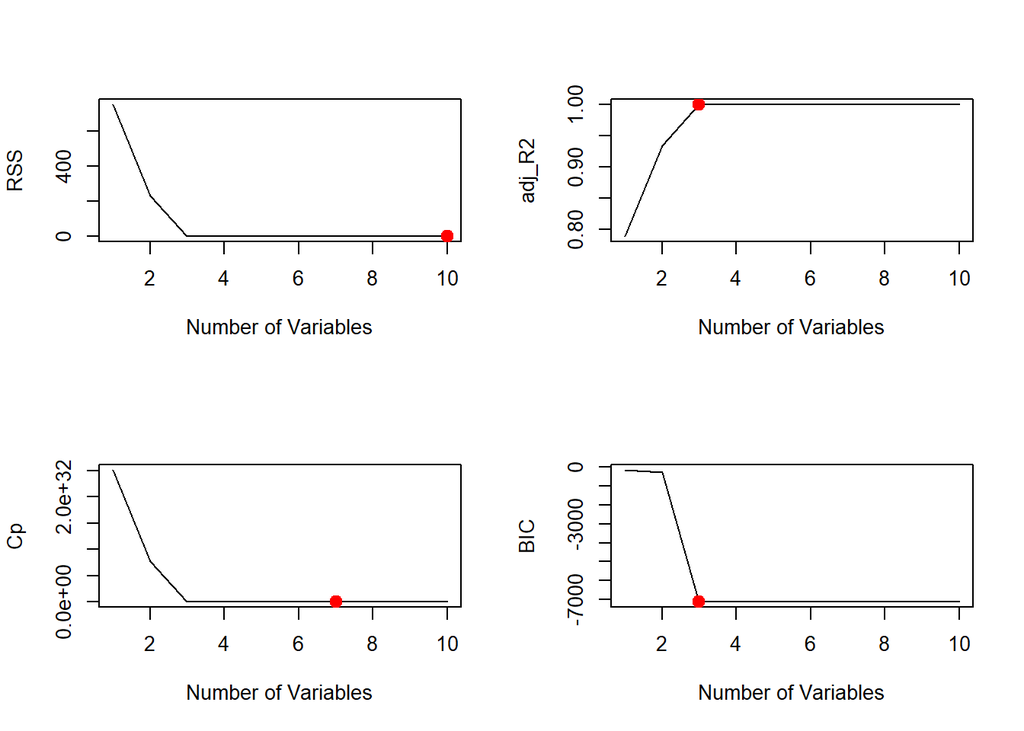

```r
# backward
fm_bwd <- regsubsets(y ~ poly(x, 10, raw = TRUE), data = df, nvmax = 10, method = "forward")
fm_bwd_sum <- summary(fm_bwd)
min_rss <- which.min(fm_bwd_sum$rss)
max_adjr2 <- which.max(fm_bwd_sum$adjr2)
min_cp <- which.min(fm_bwd_sum$cp)
min_bic <- which.min(fm_bwd_sum$bic)
par(mfrow = c(2, 2))
plot(fm_bwd_sum$rss, xlab = "Number of Variables", ylab = "RSS", type = "l")
points(min_rss, fm_bwd_sum$rss[min_rss], col = "red", cex = 2, pch = 20)
plot(fm_bwd_sum$adjr2, xlab = "Number of Variables", ylab = "adj_R2", type = "l")
points(max_adjr2, fm_bwd_sum$adjr2[max_adjr2], col = "red", cex = 2, pch = 20)
plot(fm_bwd_sum$cp, xlab = "Number of Variables", ylab = "Cp", type = "l")
points(min_cp, fm_bwd_sum$cp[min_cp], col = "red", cex = 2, pch = 20)
plot(fm_bwd_sum$bic, xlab = "Number of Variables", ylab = "BIC", type = "l")
points(min_bic, fm_bwd_sum$bic[min_bic], col = "red", cex = 2, pch = 20)
```

5. 结果表明，lasso能够选出最优模型，系数和真实模型基本一致

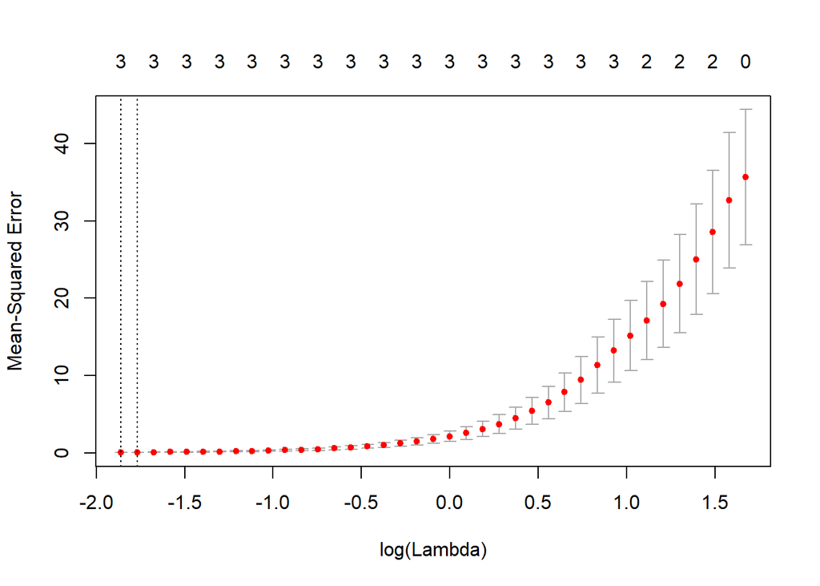

```r
library(glmnet)
x_mat <- model.matrix(y ~ poly(x, 10, raw = TRUE), df)[, -1]
lasso_fit <- glmnet(x_mat, y, alpha = 1)
set.seed(1)
cv_out <- cv.glmnet(x_mat, y, alpha = 1)
par(mfrow = c(1,1))
plot(cv_out)
```

```r
best_lambda <- cv_out$lambda.min
coef(lasso_fit, s = best_lambda)
```

```
## 11 x 1 sparse Matrix of class "dgCMatrix"
##                                   1
## (Intercept)               4.1077343
## poly(x, 10, raw = TRUE)1  2.9170537
## poly(x, 10, raw = TRUE)2  1.8879925
## poly(x, 10, raw = TRUE)3  0.9743325
## poly(x, 10, raw = TRUE)4  .
## poly(x, 10, raw = TRUE)5  .
## poly(x, 10, raw = TRUE)6  .
## poly(x, 10, raw = TRUE)7  .
## poly(x, 10, raw = TRUE)8  .
## poly(x, 10, raw = TRUE)9  .
## poly(x, 10, raw = TRUE)10 .
```

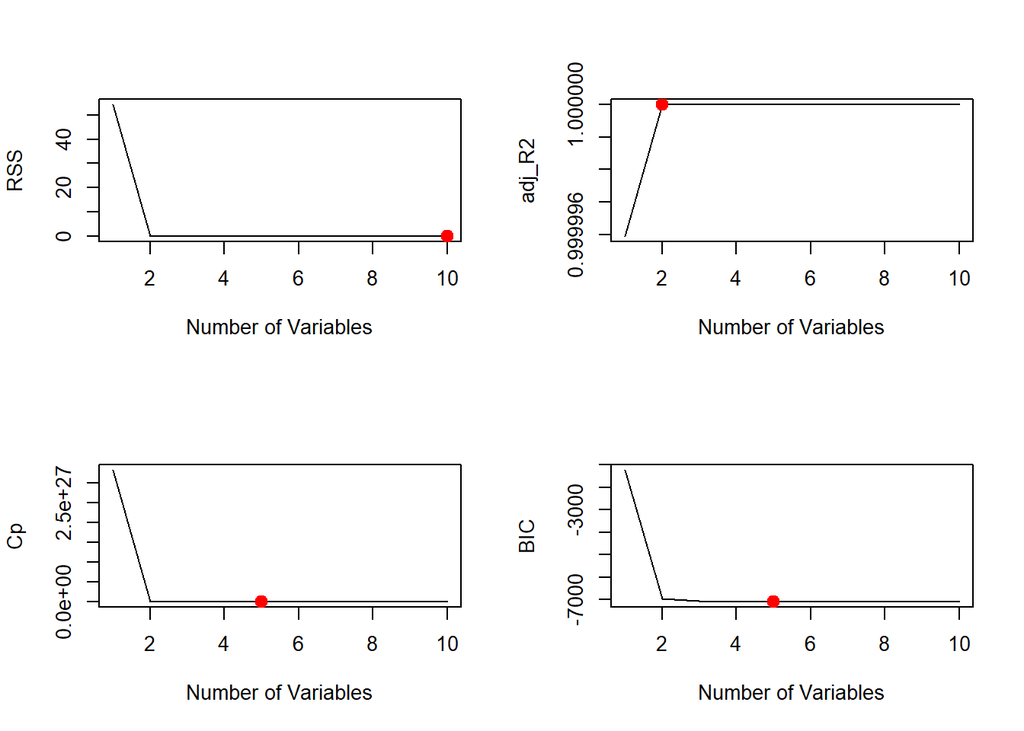

```r
beta7 <- 7
y_f <- beta0 + beta7*x^7 + epsilon
df3 <- data.frame(
  x,
  y_f
)

fm_full <- regsubsets(y_f ~ poly(x, 10, raw = TRUE), data = df3, nvmax = 10)
fm_full_sum <- summary(fm_full)
fm_full_sum <- summary(fm_full)
min_rss <- which.min(fm_full_sum$rss)
max_adjr2 <- which.max(fm_full_sum$adjr2)
min_cp <- which.min(fm_full_sum$cp)
min_bic <- which.min(fm_full_sum$bic)
par(mfrow = c(2, 2))
plot(fm_full_sum$rss, xlab = "Number of Variables", ylab = "RSS", type = "l")
points(min_rss, fm_full_sum$rss[min_rss], col = "red", cex = 2, pch = 20)
plot(fm_full_sum$adjr2, xlab = "Number of Variables", ylab = "adj_R2", type = "l")
points(max_adjr2, fm_full_sum$adjr2[max_adjr2], col = "red", cex = 2, pch = 20)
plot(fm_full_sum$cp, xlab = "Number of Variables", ylab = "Cp", type = "l")
points(min_cp, fm_full_sum$cp[min_cp], col = "red", cex = 2, pch = 20)
plot(fm_full_sum$bic, xlab = "Number of Variables", ylab = "BIC", type = "l")
points(min_bic, fm_full_sum$bic[min_bic], col = "red", cex = 2, pch = 20)
```

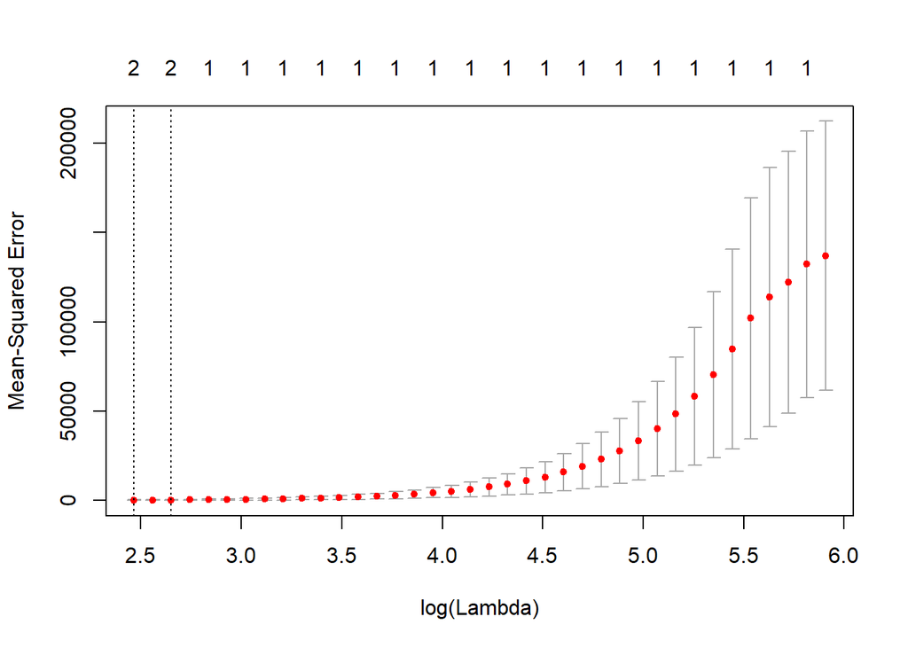

```r
x_mat2 <- model.matrix(y_f ~ poly(x, 10, raw = TRUE), df3)[, -1]
lasso_ <- glmnet(x_mat2, y_f, alpha = 1)
cv_out2 <- cv.glmnet(x_mat2, y_f, alpha = 1)
par(mfrow = c(1, 1))
plot(cv_out2)
```

```r
best_lambda2 <- cv_out2$lambda.min
coef(lasso_, s = best_lambda2)
```

```
## 11 x 1 sparse Matrix of class "dgCMatrix"
##                                   1
## (Intercept)               4.6353256
## poly(x, 10, raw = TRUE)1  .
## poly(x, 10, raw = TRUE)2  .
## poly(x, 10, raw = TRUE)3  .
## poly(x, 10, raw = TRUE)4  .
## poly(x, 10, raw = TRUE)5  0.1254289
## poly(x, 10, raw = TRUE)6  .
## poly(x, 10, raw = TRUE)7  6.7595925
## poly(x, 10, raw = TRUE)8  .
## poly(x, 10, raw = TRUE)9  .
## poly(x, 10, raw = TRUE)10 .
```

### 9.

```r
library(ISLR)
library(pls)
summary(College)
```

```
##  Private        Apps           Accept          Enroll       Top10perc
##  No :212   Min.   :   81   Min.   :   72   Min.   :  35   Min.   : 1.00
##  Yes:565   1st Qu.:  776   1st Qu.:  604   1st Qu.: 242   1st Qu.:15.00
##            Median : 1558   Median : 1110   Median : 434   Median :23.00
##            Mean   : 3002   Mean   : 2019   Mean   : 780   Mean   :27.56
##            3rd Qu.: 3624   3rd Qu.: 2424   3rd Qu.: 902   3rd Qu.:35.00
##            Max.   :48094   Max.   :26330   Max.   :6392   Max.   :96.00
##    Top25perc      F.Undergrad     P.Undergrad         Outstate
##  Min.   :  9.0   Min.   :  139   Min.   :    1.0   Min.   : 2340
##  1st Qu.: 41.0   1st Qu.:  992   1st Qu.:   95.0   1st Qu.: 7320
##  Median : 54.0   Median : 1707   Median :  353.0   Median : 9990
##  Mean   : 55.8   Mean   : 3700   Mean   :  855.3   Mean   :10441
##  3rd Qu.: 69.0   3rd Qu.: 4005   3rd Qu.:  967.0   3rd Qu.:12925
##  Max.   :100.0   Max.   :31643   Max.   :21836.0   Max.   :21700
##    Room.Board       Books           Personal         PhD
##  Min.   :1780   Min.   :  96.0   Min.   : 250   Min.   :  8.00
##  1st Qu.:3597   1st Qu.: 470.0   1st Qu.: 850   1st Qu.: 62.00
##  Median :4200   Median : 500.0   Median :1200   Median : 75.00
##  Mean   :4358   Mean   : 549.4   Mean   :1341   Mean   : 72.66
##  3rd Qu.:5050   3rd Qu.: 600.0   3rd Qu.:1700   3rd Qu.: 85.00
##  Max.   :8124   Max.   :2340.0   Max.   :6800   Max.   :103.00
##     Terminal       S.F.Ratio      perc.alumni        Expend
##  Min.   : 24.0   Min.   : 2.50   Min.   : 0.00   Min.   : 3186
##  1st Qu.: 71.0   1st Qu.:11.50   1st Qu.:13.00   1st Qu.: 6751
##  Median : 82.0   Median :13.60   Median :21.00   Median : 8377
##  Mean   : 79.7   Mean   :14.09   Mean   :22.74   Mean   : 9660
##  3rd Qu.: 92.0   3rd Qu.:16.50   3rd Qu.:31.00   3rd Qu.:10830
##  Max.   :100.0   Max.   :39.80   Max.   :64.00   Max.   :56233
##    Grad.Rate
##  Min.   : 10.00
##  1st Qu.: 53.00
##  Median : 65.00
##  Mean   : 65.46
##  3rd Qu.: 78.00
##  Max.   :118.00
```

```r
# no NA data

set.seed(1)
n <- nrow(College)
train <- sample(1:n, ceiling(0.7*n))
train_set <- College[train, ]
test_set <- College[-train, ]
```

```r
lm_fit <- lm(Apps ~ ., data = train_set)
lm_pred <- predict(lm_fit, test_set)
lm_mse <- mean((lm_pred - test_set$Apps)^2)
```

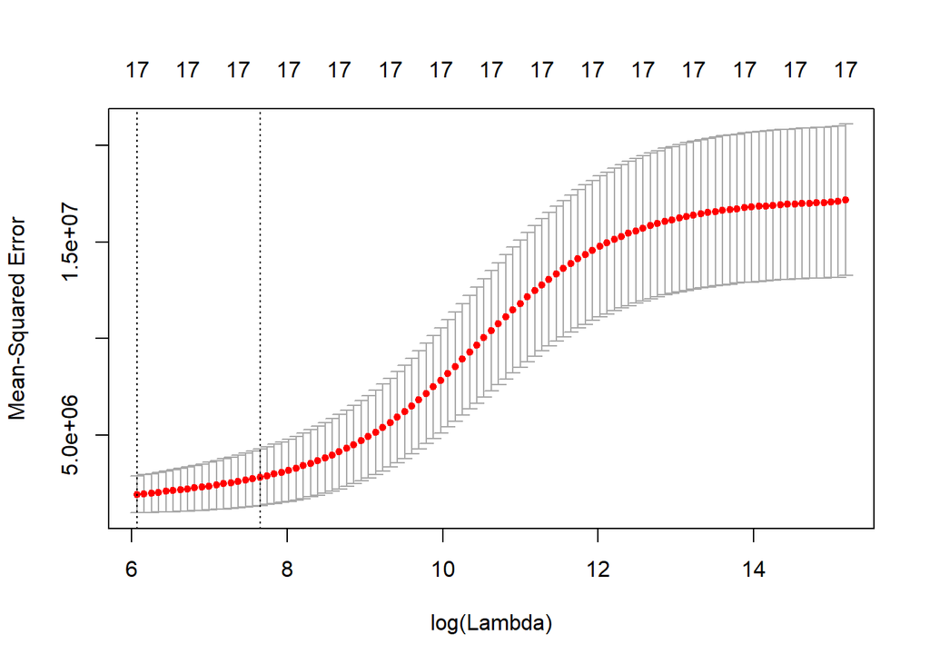

```r
train_x <- model.matrix(Apps ~ ., data = train_set)[, -1]
test_x <- model.matrix(Apps ~ ., data = test_set)[, -1]
ridge_fit <- glmnet(train_x, train_set$Apps, alpha = 0)
cv_ridge <- cv.glmnet(train_x, train_set$Apps, alpha = 0)
plot(cv_ridge)
```

```r
ridge_best_lam <- cv_ridge$lambda.min
ridge_pred <- predict(ridge_fit, s = ridge_best_lam, newx = test_x)
ridge_mse <- mean((ridge_pred - test_set$Apps)^2)
```

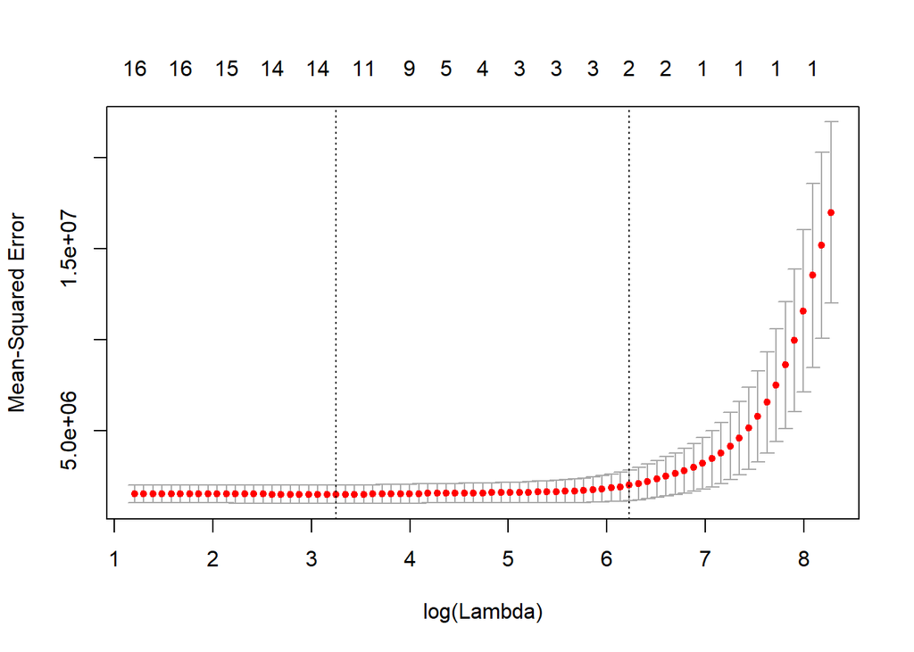

```r
lasso_fit <- glmnet(train_x, train_set$Apps, alpha = 1)
cv_lasso <- cv.glmnet(train_x, train_set$Apps, alpha = 1)
plot(cv_lasso)
```

```r
lasso_best_lam <- cv_lasso$lambda.min
lasso_pred <- predict(ridge_fit, s = lasso_best_lam, newx = test_x)
lasso_mse <- mean((lasso_pred - test_set$Apps)^2)
coef(lasso_fit, s = lasso_best_lam)
```

```
## 18 x 1 sparse Matrix of class "dgCMatrix"
##                         1
## (Intercept) -578.80716997
## PrivateYes  -411.93785668
## Accept         1.49251513
## Enroll        -0.26679903
## Top10perc     30.98948953
## Top25perc     -0.06033137
## F.Undergrad    .
## P.Undergrad    .
## Outstate      -0.05098141
## Room.Board     0.14127719
## Books          .
## Personal       .
## PhD           -2.07607487
## Terminal      -6.75788347
## S.F.Ratio      .
## perc.alumni   -1.72123995
## Expend         0.06062484
## Grad.Rate      4.24623450
```

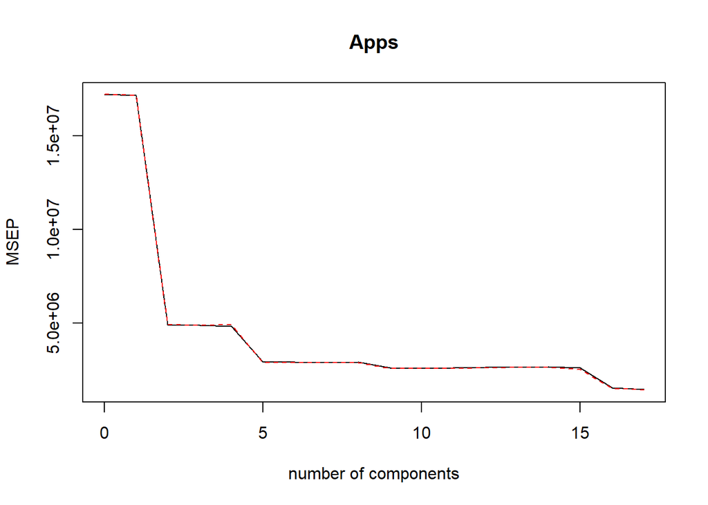

```r
pcr_fit <- pcr(Apps ~ ., data = train_set, scale = TRUE, validation = "CV")
validationplot(pcr_fit, val.type = "MSEP")
```

```r
m <- pcr_fit$ncomp
pcr_pred <- predict(pcr_fit, test_x, ncomp = m)
pcr_mse <- mean((pcr_pred - test_set$Apps)^2)
```

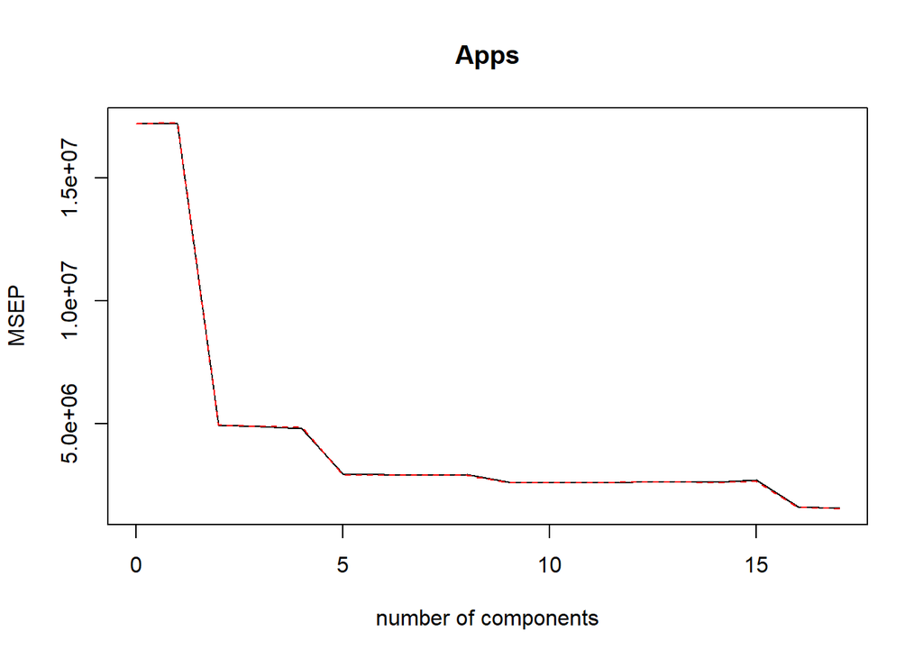

```r
pls_fit <- pcr(Apps ~ ., data = train_set, scale = TRUE, validation = "CV")
validationplot(pls_fit, val.type = "MSEP")
```

```r
m <- pls_fit$ncomp
pls_pred <- predict(pls_fit, test_x, ncomp = m)
pls_mse <- mean((pls_pred - test_set$Apps)^2)
```

7. 比较各模型的MSE

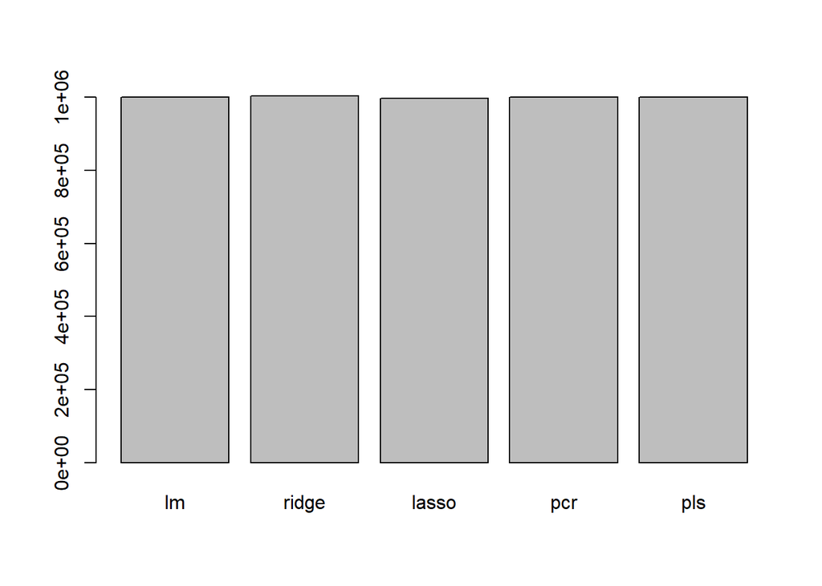

```r
mse <- c(lm_mse, ridge_mse, lasso_mse, pcr_mse, pls_mse)
names(mse) <- c("lm", "ridge", "lasso", "pcr", "pls")
barplot(mse)
```

### 10.

1. 生成模拟数据

```r
library(leaps)
p <- 20
n <- 1000
set.seed(12)
epsilon <- rnorm(n)
mat <- matrix(rnorm(p*n), nrow = 1000)
mat2 <- cbind(rep(1,n), mat)
betas <- sample(-5:5, 21, replace = TRUE)
zero <- sample(1:20, 6)
betas[zero] <- 0
betas
```

```
##  [1] -3  1  4  0  0  5  3  2  3  0  0  0  4  3 -3 -1 -1  5  0 -4  5
```

```r
y <- mat2%*%betas + epsilon
mat3 <- cbind(mat2[, -1], y)
df <- as.data.frame(mat3)
colnames(df) <- c(paste("x", 1:20, sep = ""), "y")
```

2. 划分数据集

```r
set.seed(1)
train <- sample(1:n, 100)
train_set <- df[train, ]
test_set <- df[-train, ]
```

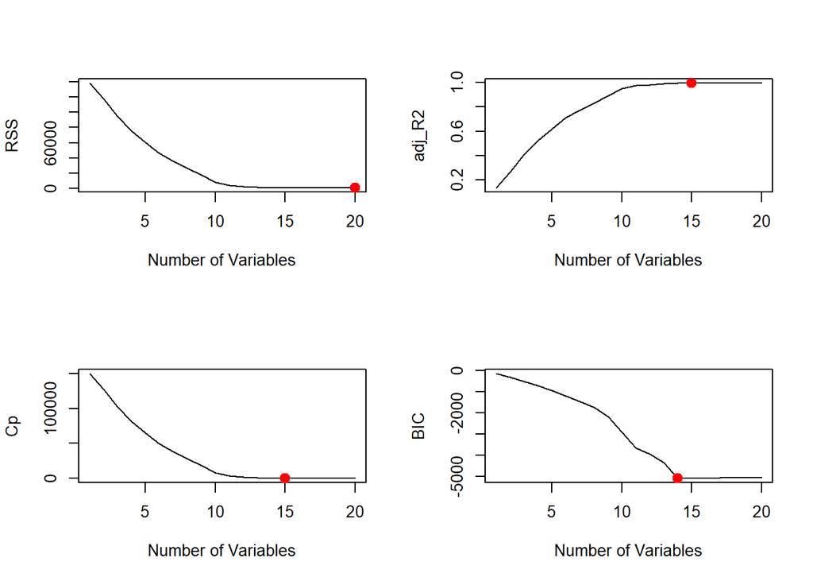

```r
fm_full <- regsubsets(y ~ ., data = df, nvmax = 20)
fm_sum <- summary(fm_full)

min_rss <- which.min(fm_sum$rss)
max_adjr2 <- which.max(fm_sum$adjr2)
min_cp <- which.min(fm_sum$cp)
min_bic <- which.min(fm_sum$bic)
par(mfrow = c(2, 2))
plot(fm_sum$rss, xlab = "Number of Variables", ylab = "RSS", type = "l")
points(min_rss, fm_sum$rss[min_rss], col = "red", cex = 2, pch = 20)
plot(fm_sum$adjr2, xlab = "Number of Variables", ylab = "adj_R2", type = "l")
points(max_adjr2, fm_sum$adjr2[max_adjr2], col = "red", cex = 2, pch = 20)
plot(fm_sum$cp, xlab = "Number of Variables", ylab = "Cp", type = "l")
points(min_cp, fm_sum$cp[min_cp], col = "red", cex = 2, pch = 20)
plot(fm_sum$bic, xlab = "Number of Variables", ylab = "BIC", type = "l")
points(min_bic, fm_sum$bic[min_bic], col = "red", cex = 2, pch = 20)
```

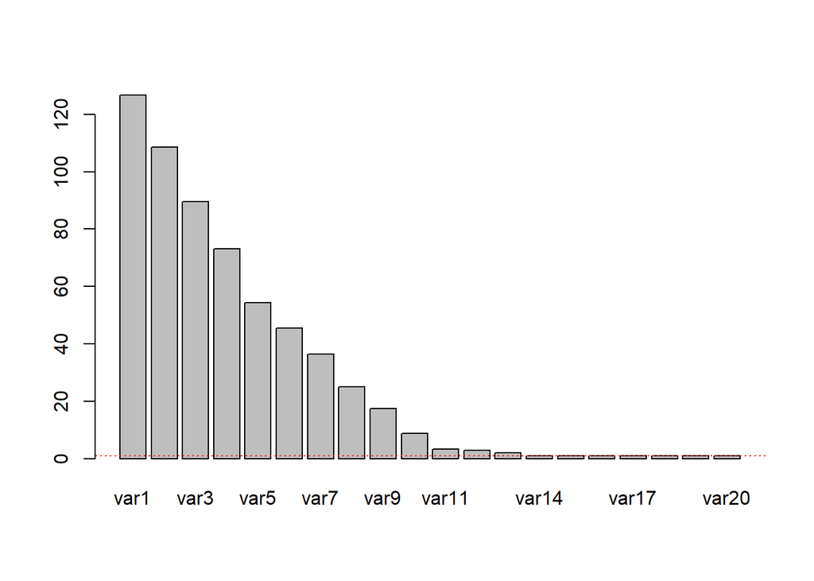

```r
val_err <- rep(0, p)
train_mat <- model.matrix(y ~ ., data = train_set)
for (i in 1:p){
  coef_i <- coef(fm_full, id = i)
  selected_feature <- names(coef_i)
  pred <- train_mat[, selected_feature] %*% coef_i
  mse <- mean((pred - train_set$y)^2)
  val_err[i] <- mse
}
names(val_err) <- paste("var", 1:p, sep = "")
par(mfrow = c(1,1))
barplot(val_err)
abline(h = min(val_err), col = "red", lty = 3)
```

```r
# 最优变量数
which.min(val_err)
```

```
## var14
##    14
```

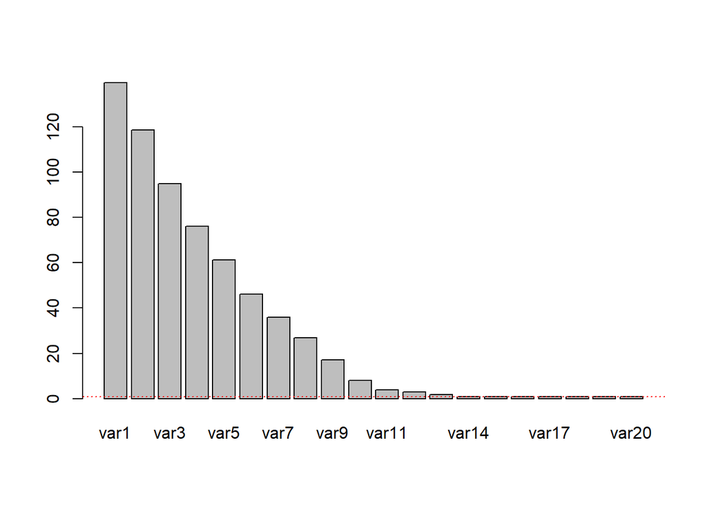

```r
val_err2 <- rep(0, p)
test_mat <- model.matrix(y ~ ., data = test_set)
for (i in 1:p) {
  coef_i <- coef(fm_full, id = i)
  selected_feature <- names(coef_i)
  pred <- test_mat[, selected_feature] %*% coef_i
  mse <- mean((pred - test_set$y)^2)
  val_err2[i] <- mse
}
names(val_err2) <- paste("var", 1:p, sep = "")
barplot(val_err2)
abline(h = min(val_err2), col = "red", lty = 3)
```

```r
which.min(val_err2)
```

```
## var20
##    20
```

5. 如上所示，全模型(变量数为20)时，测试MSE最小，但是当变量数>=13时，MSE就基本相同了，这个时候其实可以优选变量数少的模型。  
   可以通过调整随机种子来调整数据生成

```r
coef(fm_full, id = 20)
```

```
## (Intercept)          x1          x2          x3          x4          x5
## -3.02021009  0.99272641  4.07104653 -0.05200796 -0.01320063  5.01088356
##          x6          x7          x8          x9         x10         x11
##  3.03685242  2.04926289  3.02695849 -0.00651118  0.01930571  0.02527992
##         x12         x13         x14         x15         x16         x17
##  4.05653193  3.06444884 -3.00390066 -1.00843283 -1.01112409  4.98700256
##         x18         x19         x20
##  0.01551774 -4.01666697  5.00419955
```

```r
betas
```

```
##  [1] -3  1  4  0  0  5  3  2  3  0  0  0  4  3 -3 -1 -1  5  0 -4  5
```

二者的系数很接近，在真实模型中beta为0的系数在全模型中对应的系数也很接近0

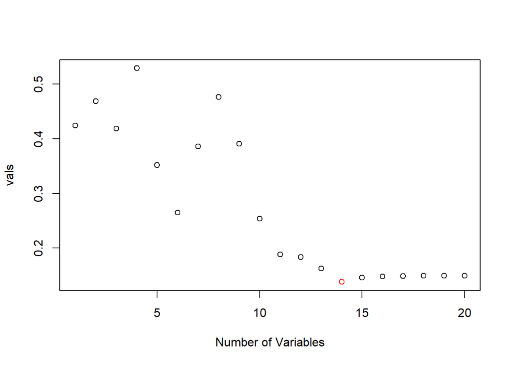

```r
names(betas) <- c("(Intercept)", paste("x", 1:p, sep = ""))
vals <- rep(0, p)
for (r in 1:p) {
  coef_r <- coef(fm_full, id = r)
  vals[r] <- sqrt(sum((betas[names(coef_r)] - coef_r)^2))
}
plot(1:p, vals, xlab = "Number of Variables")
points(which.min(vals), min(vals), col = "red")
```